# Analiza danych

Analiza danych (zwane również rozpoznawcza analiza danych lub EDA ) jest rodziną metod statystycznych, których główne cechy to być wielowymiarowy i opisowe. W sensie francuskim terminologia „analiza danych” oznacza zatem podzbiór tego, co bardziej ogólnie nazywa się statystyką wielowymiarową . Niektóre metody, w większości geometryczne , pomagają uwydatnić zależności, które mogą istnieć między różnymi danymi i uzyskać z nich informacje statystyczne, które umożliwiają bardziej zwięzłe opisanie głównych informacji zawartych w tych danych.

### Celem analizy jest zbadanie danych pasażerów statku Titanic, który zatonął w kwietniu 1912 roku.

Analiza pozwala:

Zidentyfikować czynniki wpływające na przeżywalność pasażerów (np. płeć, wiek, klasa).

Przeanalizować rozkłady zmiennych liczbowych i kategorycznych, w tym wykryć wartości odstające.

Zbadać relacje między zmiennymi, np. wpływ obecności rodziny na szanse przeżycia.

Dzięki wizualizacjom, takim jak histogramy, boxploty, violin ploty czy wykresy słupkowe, możliwe jest szybkie wychwycenie nierówności, outlierów i struktur danych, co stanowi podstawę dalszych analiz statystycznych i predykcyjnych.

## O Danych

Dane o pasażerach Titanica

Zbiór danych zawiera informacje o pasażerach RMS Titanic, który zatonął 15 kwietnia 1912 roku po zderzeniu z górą lodową. Dane obejmują takie atrybuty jak klasa podróży, wiek, płeć, liczba rodzeństwa/małżonków na pokładzie, liczba rodziców/dzieci na pokładzie, cena biletu oraz miejsce zaokrętowania.

Zbiór zawiera także informację o tym, czy pasażer przeżył katastrofę.

Titanic przewoził ponad 2,200 osób, z czego ponad 1,500 zginęło, co czyni tę katastrofę jedną z najbardziej tragicznych w historii morskiej.

Kolumny:

- **pclass** - Klasa biletu
- **survived** - Czy pasażer przeżył katastrofę
- **name** - Imię i nazwisko pasażera
- **sex** - Płeć pasażera
- **age** - Wiek pasażera
- **sibsp** - Liczba rodzeństwa/małżonków na pokładzie
- **parch** - Liczba rodziców/dzieci na pokładzie
- **ticket** - Numer biletu
- **fare** - Cena biletu
- **cabin** - Numer kabiny
- **embarked** - Port, w którym pasażer wszedł na pokład (C = Cherbourg, Q = Queenstown, S = Southampton)
- **boat** - Numer łodzi ratunkowej
- **body** - Numer ciała (jeśli pasażer nie przeżył i ciało zostało odnalezione)
- **home.dest** - Miejsce docelowe

[figure not shown]

## 1. Ogólny przegląd danych

|  | pclass | survived | name | sex | age | sibsp | parch | ticket | fare | cabin | embarked | boat | body | home.dest |
| --- | --- | --- | --- | --- | --- | --- | --- | --- | --- | --- | --- | --- | --- | --- |
| 0 | 1.0 | 1.0 | Allen, Miss. Elisabeth Walton | female | 29.0000 | 0.0 | 0.0 | 24160 | 211.3375 | B5 | S | 2 | NaN | St Louis, MO |
| 1 | 1.0 | 1.0 | Allison, Master. Hudson Trevor | male | 0.9167 | 1.0 | 2.0 | 113781 | 151.5500 | C22 C26 | S | 11 | NaN | Montreal, PQ / Chesterville, ON |
| 2 | 1.0 | 0.0 | Allison, Miss. Helen Loraine | female | 2.0000 | 1.0 | 2.0 | 113781 | 151.5500 | C22 C26 | S | NaN | NaN | Montreal, PQ / Chesterville, ON |
| 3 | 1.0 | 0.0 | Allison, Mr. Hudson Joshua Creighton | male | 30.0000 | 1.0 | 2.0 | 113781 | 151.5500 | C22 C26 | S | NaN | 135.0 | Montreal, PQ / Chesterville, ON |
| 4 | 1.0 | 0.0 | Allison, Mrs. Hudson J C (Bessie Waldo Daniels) | female | 25.0000 | 1.0 | 2.0 | 113781 | 151.5500 | C22 C26 | S | NaN | NaN | Montreal, PQ / Chesterville, ON |
| ... | ... | ... | ... | ... | ... | ... | ... | ... | ... | ... | ... | ... | ... | ... |
| 1305 | 3.0 | 0.0 | Zabour, Miss. Thamine | female | NaN | 1.0 | 0.0 | 2665 | 14.4542 | NaN | C | NaN | NaN | NaN |
| 1306 | 3.0 | 0.0 | Zakarian, Mr. Mapriededer | male | 26.5000 | 0.0 | 0.0 | 2656 | 7.2250 | NaN | C | NaN | 304.0 | NaN |
| 1307 | 3.0 | 0.0 | Zakarian, Mr. Ortin | male | 27.0000 | 0.0 | 0.0 | 2670 | 7.2250 | NaN | C | NaN | NaN | NaN |
| 1308 | 3.0 | 0.0 | Zimmerman, Mr. Leo | male | 29.0000 | 0.0 | 0.0 | 315082 | 7.8750 | NaN | S | NaN | NaN | NaN |
| 1309 | NaN | NaN | NaN | NaN | NaN | NaN | NaN | NaN | NaN | NaN | NaN | NaN | NaN | NaN |

1310 rows × 14 columns

|  | Klasa | Ocalony | nazwisko | imiona | Płeć | Wiek | Rodzeństwo//Współmałżonek | Rodzice/dzieci | Bilet | Cena | Kabina | wszedł na pokład | Łódź | Ciało | Miejsce docelowe |
| --- | --- | --- | --- | --- | --- | --- | --- | --- | --- | --- | --- | --- | --- | --- | --- |
| 1 | 1.0 | 1.0 | Allen | Miss. Elisabeth Walton | female | 29.0000 | 0.0 | 0.0 | 24160 | 211.3375 | B5 | S | 2 | NaN | St Louis, MO |
| 2 | 1.0 | 1.0 | Allison | Master. Hudson Trevor | male | 0.9167 | 1.0 | 2.0 | 113781 | 151.5500 | C22 C26 | S | 11 | NaN | Montreal, PQ / Chesterville, ON |
| 3 | 1.0 | 0.0 | Allison | Miss. Helen Loraine | female | 2.0000 | 1.0 | 2.0 | 113781 | 151.5500 | C22 C26 | S | NaN | NaN | Montreal, PQ / Chesterville, ON |
| 4 | 1.0 | 0.0 | Allison | Mr. Hudson Joshua Creighton | male | 30.0000 | 1.0 | 2.0 | 113781 | 151.5500 | C22 C26 | S | NaN | 135.0 | Montreal, PQ / Chesterville, ON |
| 5 | 1.0 | 0.0 | Allison | Mrs. Hudson J C (Bessie Waldo Daniels) | female | 25.0000 | 1.0 | 2.0 | 113781 | 151.5500 | C22 C26 | S | NaN | NaN | Montreal, PQ / Chesterville, ON |
| ... | ... | ... | ... | ... | ... | ... | ... | ... | ... | ... | ... | ... | ... | ... | ... |
| 1306 | 3.0 | 0.0 | Zabour | Miss. Thamine | female | NaN | 1.0 | 0.0 | 2665 | 14.4542 | NaN | C | NaN | NaN | NaN |
| 1307 | 3.0 | 0.0 | Zakarian | Mr. Mapriededer | male | 26.5000 | 0.0 | 0.0 | 2656 | 7.2250 | NaN | C | NaN | 304.0 | NaN |
| 1308 | 3.0 | 0.0 | Zakarian | Mr. Ortin | male | 27.0000 | 0.0 | 0.0 | 2670 | 7.2250 | NaN | C | NaN | NaN | NaN |
| 1309 | 3.0 | 0.0 | Zimmerman | Mr. Leo | male | 29.0000 | 0.0 | 0.0 | 315082 | 7.8750 | NaN | S | NaN | NaN | NaN |
| 1310 | NaN | NaN | NaN | NaN | NaN | NaN | NaN | NaN | NaN | NaN | NaN | NaN | NaN | NaN | NaN |

1310 rows × 15 columns

```
<class 'pandas.core.frame.DataFrame'>
RangeIndex: 1310 entries, 1 to 1310
Data columns (total 15 columns):
 #   Column                     Non-Null Count  Dtype
---  ------                     --------------  -----
 0   Klasa                      1309 non-null   float64
 1   Ocalony                    1309 non-null   float64
 2   nazwisko                   1309 non-null   object
 3   imiona                     1309 non-null   object
 4   Płeć                       1309 non-null   object
 5   Wiek                       1046 non-null   float64
 6   Rodzeństwo//Współmałżonek  1309 non-null   float64
 7   Rodzice/dzieci             1309 non-null   float64
 8   Bilet                      1309 non-null   object
 9   Cena                       1308 non-null   float64
 10  Kabina                     295 non-null    object
 11  wszedł na pokład           1307 non-null   object
 12  Łódź                       486 non-null    object
 13  Ciało                      121 non-null    float64
 14  Miejsce docelowe           745 non-null    object
dtypes: float64(7), object(8)
memory usage: 153.6+ KB
```

```
Klasa                           3
Ocalony                         2
nazwisko                      875
imiona                       1142
Płeć                            2
Wiek                           98
Rodzeństwo//Współmałżonek       7
Rodzice/dzieci                  8
Bilet                         929
Cena                          281
Kabina                        186
wszedł na pokład                3
Łódź                           27
Ciało                         121
Miejsce docelowe              369
dtype: int64
```

## 2. Analiza brakujących wartości

|  | Klasa | Ocalony | nazwisko | imiona | Płeć | Wiek | Rodzeństwo//Współmałżonek | Rodzice/dzieci | Bilet | Cena | Kabina | wszedł na pokład | Łódź | Ciało | Miejsce docelowe |
| --- | --- | --- | --- | --- | --- | --- | --- | --- | --- | --- | --- | --- | --- | --- | --- |
| 1 | False | False | False | False | False | False | False | False | False | False | False | False | False | True | False |
| 2 | False | False | False | False | False | False | False | False | False | False | False | False | False | True | False |
| 3 | False | False | False | False | False | False | False | False | False | False | False | False | True | True | False |
| 4 | False | False | False | False | False | False | False | False | False | False | False | False | True | False | False |
| 5 | False | False | False | False | False | False | False | False | False | False | False | False | True | True | False |
| ... | ... | ... | ... | ... | ... | ... | ... | ... | ... | ... | ... | ... | ... | ... | ... |
| 1306 | False | False | False | False | False | True | False | False | False | False | True | False | True | True | True |
| 1307 | False | False | False | False | False | False | False | False | False | False | True | False | True | False | True |
| 1308 | False | False | False | False | False | False | False | False | False | False | True | False | True | True | True |
| 1309 | False | False | False | False | False | False | False | False | False | False | True | False | True | True | True |
| 1310 | True | True | True | True | True | True | True | True | True | True | True | True | True | True | True |

1310 rows × 15 columns

```
Klasa                           1
Ocalony                         1
nazwisko                        1
imiona                          1
Płeć                            1
Wiek                          264
Rodzeństwo//Współmałżonek       1
Rodzice/dzieci                  1
Bilet                           1
Cena                            2
Kabina                       1015
wszedł na pokład                3
Łódź                          824
Ciało                        1189
Miejsce docelowe              565
dtype: int64
```

```
Klasa                         0.08
Ocalony                       0.08
nazwisko                      0.08
imiona                        0.08
Płeć                          0.08
Wiek                         20.15
Rodzeństwo//Współmałżonek     0.08
Rodzice/dzieci                0.08
Bilet                         0.08
Cena                          0.15
Kabina                       77.48
wszedł na pokład              0.23
Łódź                         62.90
Ciało                        90.76
Miejsce docelowe             43.13
dtype: float64
```

## 3. Analiza pojedynczych zmiennych

```
Histogramy dla danych liczbowych:
```

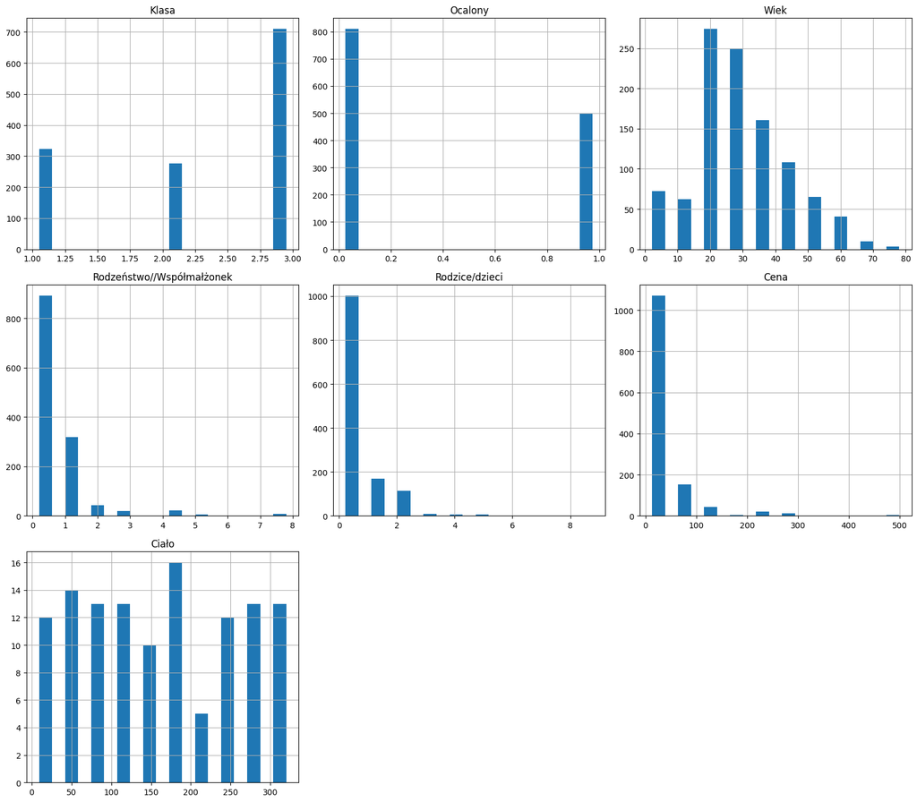

## 4. Analiza relacji między zmiennymi

```
Procent ocalonych: 38.17%
```

```
307
Klasa
1.0    16.50
2.0    85.71
3.0    95.03
dtype: float64
```

|  | nazwisko | imiona | Kabina | Klasa |
| --- | --- | --- | --- | --- |
| 14 | Barber | Miss. Ellen "Nellie" | NaN | 1.0 |
| 24 | Bidois | Miss. Rosalie | NaN | 1.0 |
| 36 | Bowen | Miss. Grace Scott | NaN | 1.0 |
| 38 | Bradley | Mr. George ("George Arthur Brayton") | NaN | 1.0 |
| 49 | Candee | Mrs. Edward (Helen Churchill Hungerford) | NaN | 1.0 |
| ... | ... | ... | ... | ... |
| 1262 | Turkula | Mrs. (Hedwig) | NaN | 3.0 |
| 1278 | Vartanian | Mr. David | NaN | 3.0 |
| 1287 | Whabee | Mrs. George Joseph (Shawneene Abi-Saab) | NaN | 3.0 |
| 1291 | Wilkes | Mrs. James (Ellen Needs) | NaN | 3.0 |
| 1301 | Yasbeck | Mrs. Antoni (Selini Alexander) | NaN | 3.0 |

307 rows × 4 columns

### Analiza powodów, dla których część ocalonych pasażerów Titanica nie miała podanego numeru kabiny w danych historycznych:

Pasażerowie, którzy przeżyli katastrofę, często byli w szoku lub wyczerpani, więc mogli nie pamiętać dokładnych szczegółów swojej kabiny, biletu czy osób z rodziny.

Niektóre manifesty i raporty opierały się na wspomnieniach ocalałych, a nie na dokumentach – co zwiększało ryzyko błędów.Dokumentacja statku była częściowo niekompletna lub zaginęła po katastrofie.

Nie wszystkie miejsca były zapisane w manifestach pasażerskich, szczególnie dla osób z niższych klas lub pasażerów, którzy przeszli na statek w drodze.

Pasażerowie klasy trzeciej często mieszkali w wielokrotnych dormitoriach, które nie miały przypisanych indywidualnych numerów kabin. W takich przypadkach „kabina” nie była faktyczną pojedynczą komórką mieszkalną, więc nie wpisywano numeru.

Część pasażerów mogła spędzać czas na statku bez formalnego zameldowania w kabinie (np. dzieci z rodzicami w jednym pomieszczeniu, stewardzi, pracownicy pokładowi).

Późniejsze zestawienia danych historycznych mogły mieć luki lub literówki, które spowodowały, że niektóre kabiny nie zostały przypisane w bazach danych

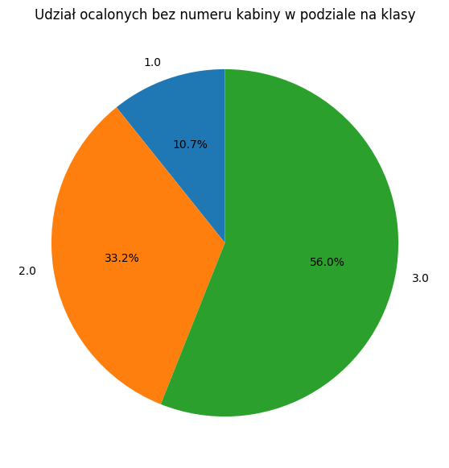

Wykres pokazuje że pasażerowie z pierwszej klasy w większości potrafili wskazać swój numer kabiny

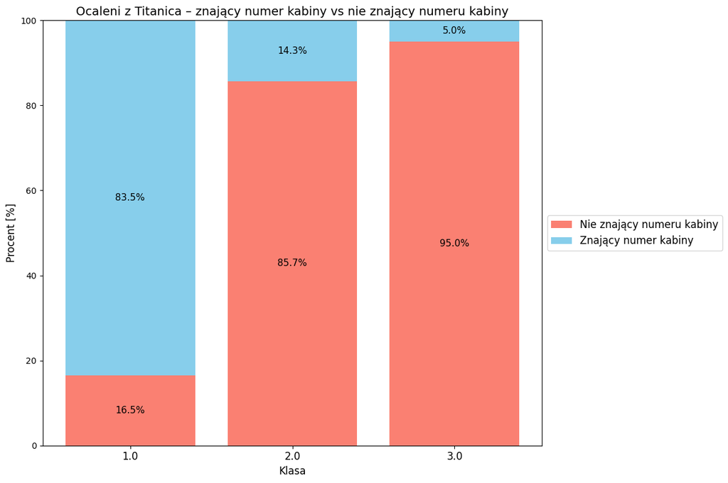

Wykres pokazuje jak niedbale traktowano klasę drugą i trzecią.

Rozbieżność w brakach danych między klasami dużo mówi nie tylko o jakości danych, ale też o realnych różnicach społecznych na Titanicu.

1 klasa – pasażerowie mieli indywidualne, przydzielone kabiny (często luksusowe apartamenty). Ich numery były dobrze udokumentowane, więc ocaleni częściej je pamiętali lub wpisano je do dokumentów.

2 i szczególnie 3 klasa – kabiny były często wieloosobowe, zatłoczone, a część pasażerów nawet nie miała przypisanej konkretnej kajuty (np. podróżowali na tzw. „open berths”).

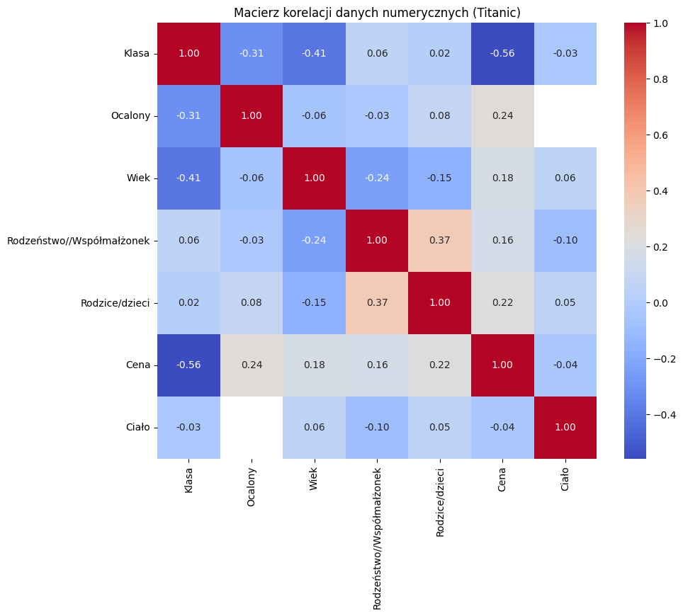

### Na podstawie macierzy korelacji wytypowałem analizy, które pokazują najważniejsze według mnie zależności w danych o Titanicu

Przeżywalność ze względu na płeć

Rodzina vs samotność – wpływ na przeżycie

Wiek i płeć w danej klasie a przeżywalność

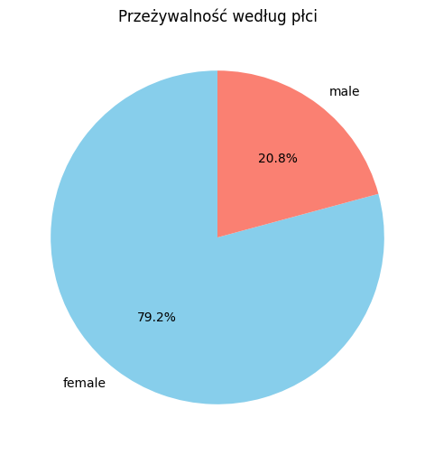

### Kobiety miały znacznie większe szanse na przeżycie

Segment „Kobiety” zwykle jest większy niż „Mężczyźni”, co oznacza wyższy odsetek ocalałych.

To odzwierciedla historyczną zasadę „women and children first” podczas ewakuacji Titanica.

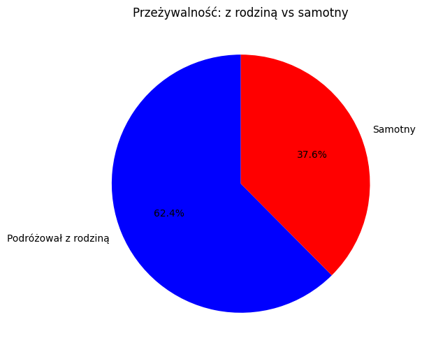

### Segment „Podróżował z rodziną” jest większy, co oznacza wyższy odsetek ocalałych w tej grupie.

Dane te pokazują, że relacje rodzinne były realnym czynnikiem ratunkowym podczas katastrofy.

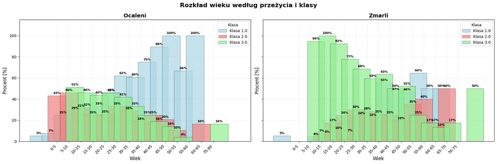

W starszych grupach wiekowych w klasie 3, procent ocalałych jest minimalny.

Widać, że wiek był istotnym czynnikiem przy ratowaniu pasażerów – dzieci i młodzież miały wyższe szanse

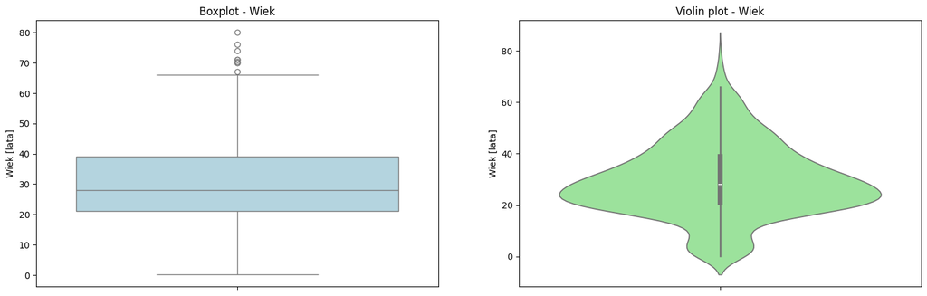

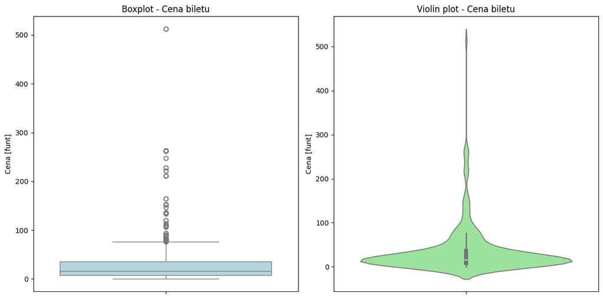

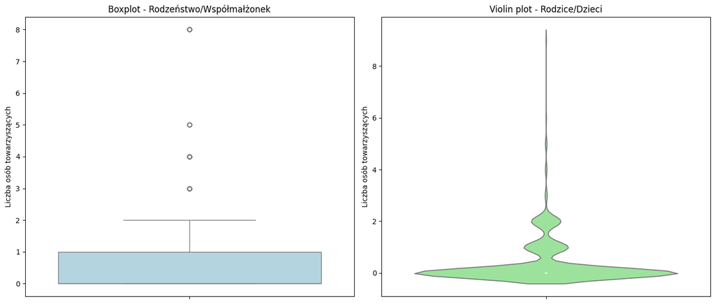

Rodzeństwo/Współmałżonek oraz Rodzice/Dzieci Większość pasażerów podróżowała samotnie (0–1 osoba). Odstające wartości: np. pasażerowie podróżujący z bardzo dużymi rodzinami (np. 6–8 osób), które są rzadkością

## 6 Podsumowanie analizy Titanica

1. Przeżywalność według płci

Kobiety miały znacznie wyższe szanse przeżycia niż mężczyźni.

Wynik ten potwierdza historyczną zasadę „kobiety i dzieci pierwsze” przy ewakuacji statku.

2. Wpływ wieku

W starszych grupach wiekowych przeżywalność spadała, szczególnie w klasie 3.

Rozkłady wieku w poszczególnych klasach pokazują, że dzieci były faktycznie preferowane przy ewakuacji.

3. Wpływ klasy społecznej

Klasa pierwsza: najwyższy procent ocalałych.

Klasa druga: umiarkowany procent ocalałych, nieco gorszy niż w klasie 1.

Klasa trzecia: zdecydowanie najniższy procent przeżycia, zwłaszcza wśród dorosłych.

Widać wyraźną zależność między pozycją społeczną a dostępem do szalup ratunkowych.

4. Wpływ obecności rodziny

Pasażerowie podróżujący z rodziną (rodzeństwo/współmałżonek lub rodzice/dzieci) mieli większe szanse przeżycia niż samotni pasażerowie.

5. Znajomość kabiny

Pasażerowie z klasy wyższej częściej podawali numer kabiny niż pasażerowie klasy 3.

Wiele osób z klasy trzeciej nie podało numeru kabiny – prawdopodobnie z powodu chaosu i dezorientacji podczas ewakuacji.

6. Podsumowanie rozkładów wiekowych

Histogramy i wykresy procentowe pokazują, że:

W klasie 3 dorosłych przeżyło bardzo niewiele osób.

Kolorowe histogramy z przenikającymi się słupkami pomagają wizualnie zidentyfikować „grupy ryzyka”.

7. Wnioski ogólne

Szanse przeżycia były silnie determinowane przez: klasę, wiek, płeć oraz obecność rodziny.

Analiza potwierdza historyczne relacje i reguły ratowania pasażerów.

Dane wskazują, że społeczne i demograficzne czynniki miały większy wpływ na przeżycie niż losowe okoliczności.

[figure not shown]

[output not shown]